# Digit Detection Project

Isaac Layton

January 26, 2016

The MNIST dataset is a popular introduction into image classification. It was created by the National Institute of Standards and Technology and contains 42,000 gray-scale pixelated digits hand-drawn by 500 participants. Each digit is recorded by measuring each pixels’ darkness level; for a 28-by-28 pixel image, this equates to 784 different variables that range from completely white to completely black. The goal of this project was to preprocess the data using dimension reduction, classify the data using machine learning and nonparametric techniques, and estimate the accuracy of the techniques using cross validation.

# Data Preprocessing

I began by creating a function to visualize what the digits looked like. Encoding the darkness as hexidecimal values and plotting the points gave a clear look at digits:

[figure not shown]

Because the data contains 42,000 observations and 784 pixel location variables, some row and column reduction was necessary to make computations faster.

Reducing the number of observations began with splitting the data into a training set and a test set. I decided to put 80% (33,600) of the digits in the training set and 20% (8400) in the test set. From there, I further split the training set into 20% (6,720) as a validation set and 80% (26,880) remaining as a training set. The validation set was choosing the best model and parameters, and the test set was to estimate the model’s performance if given more data.

The first way that I was able to reduce the number of variables was by removing all variables with a variance of 0. There’s not much usefulness for a variable that never has different values. This got rid of 76 pixel locations, most of which were the white space surrounding each digit. This leaves us with 708 variables.

From here, I conducted principal components analysis (PCA). Principal component analysis is a method of dimension reduction in which the factors of a dataset are replaced by linear combinations of all of the factors. The first linear combination, or the first principal component, represents the direction in the input space that has the most variance, with the second having the second most variance, and so on. There can as many principal components as there are factors, and they’ll each be uncorrelated with each other. Applying principal component analysis to the MNIST dataset allows 90% of the variance to be explained in just 225 variables instead of 708:

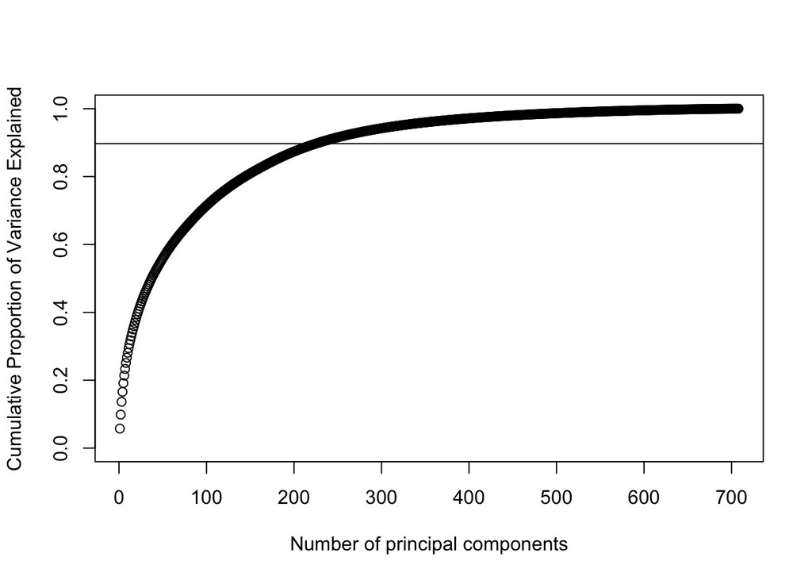

Using PCA also allows you to visualize the data easier. It wouldn’t be very informative to plot one pixel against another, and plotting more than 3 pixel locations against each other would be impossible with a single scatterplot. With PCA variables though, since they’re linear combinations of every pixel location, we can easily visualize the relationship between the digits. Plotting the first and second principal components against each other, you can start to see some patterns:

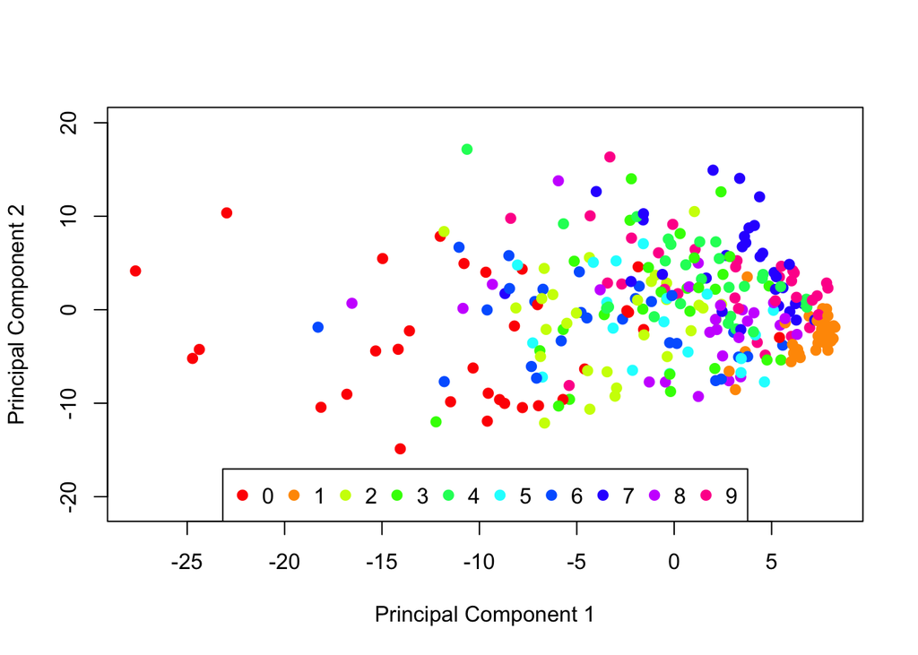